# R for Project Management

2-markdown

D-Lab

3/1/2019

# RStudio

Top left: input/script  
Bottom left: output/console  
Top right: “global” environment  
Bottom right: misc.  
- Navigate file system  
- View plots  
- Install packages  
- Access help files  
- Create documents in the “Viewer”

# Markdown

Fancy text formatting! Prepare documents that directly link to your code and vice-versa.

#### .html

After you create the .html file, double click it with your mouse and it will open in your preferred web browser.

## Other programs

- MSWord, Excel
- PDF
- LaTeX, Overleaf

## Stylizing text

Enter text by typing normally. Use hashtage to change the header size, and **wrap words in double stars** to bold text. Click this link

## Images

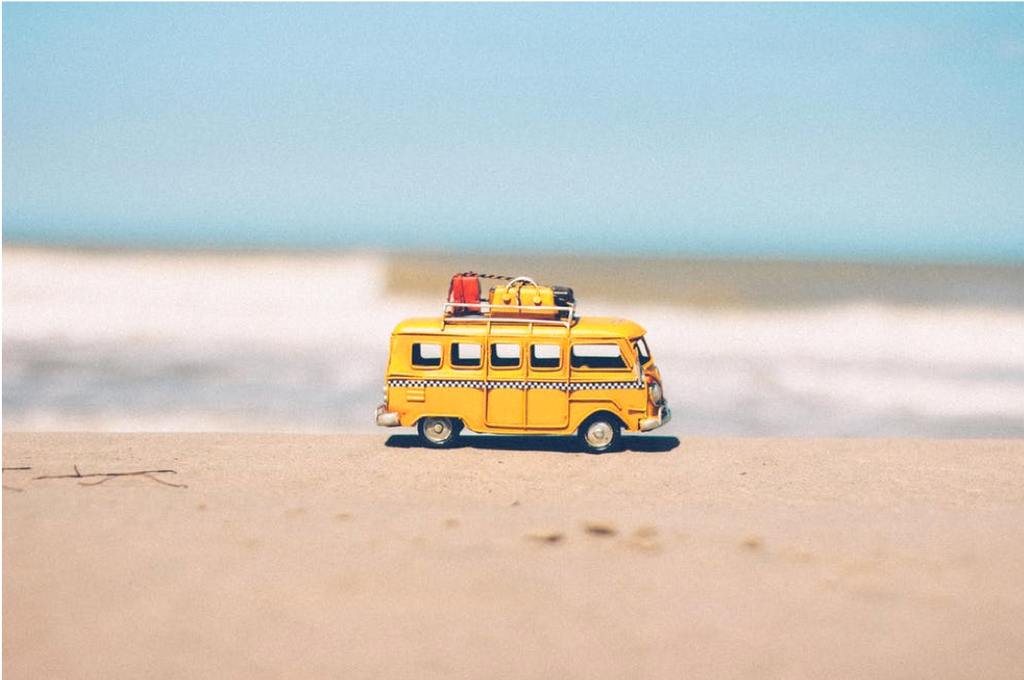

Include text like this: https://www.pexels.com/search/car/

## Example

Suppose you are interested in studying the relationships between fuel efficiency and other features of the automobile such as engine size, horsepower, weight and speed.

## Software requirements

1. Click “Clone or Download” –> “Download Zip”; extract this file to Desktop.

(Git users should use git clone)

2. Download R version 3.5.2
3. Download RStudio Open Source License FREE

Run the installers and follow the instructions for both 2) and 3) above.

## Load data

```r
mt = read.csv("~/mtcars.csv")

# Print the data
# mt

# View data summary
str(mt)
```

```
## 'data.frame':    32 obs. of  12 variables:
##  $ X   : Factor w/ 32 levels "AMC Javelin",..: 18 19 5 13 14 31 7 21 20 22 ...
##  $ mpg : num  21 21 22.8 21.4 18.7 18.1 14.3 24.4 22.8 19.2 ...
##  $ cyl : int  6 6 4 6 8 6 8 4 4 6 ...
##  $ disp: num  160 160 108 258 360 ...
##  $ hp  : int  110 110 93 110 175 105 245 62 95 123 ...
##  $ drat: num  3.9 3.9 3.85 3.08 3.15 2.76 3.21 3.69 3.92 3.92 ...
##  $ wt  : num  2.62 2.88 2.32 3.21 3.44 ...
##  $ qsec: num  16.5 17 18.6 19.4 17 ...
##  $ vs  : int  0 0 1 1 0 1 0 1 1 1 ...
##  $ am  : int  1 1 1 0 0 0 0 0 0 0 ...
##  $ gear: int  4 4 4 3 3 3 3 4 4 4 ...
##  $ carb: int  4 4 1 1 2 1 4 2 2 4 ...
```

```r
# Check out the first five rows
head(mt, n = 5)
```

```
##                   X  mpg cyl disp  hp drat    wt  qsec vs am gear carb
## 1         Mazda RX4 21.0   6  160 110 3.90 2.620 16.46  0  1    4    4
## 2     Mazda RX4 Wag 21.0   6  160 110 3.90 2.875 17.02  0  1    4    4
## 3        Datsun 710 22.8   4  108  93 3.85 2.320 18.61  1  1    4    1
## 4    Hornet 4 Drive 21.4   6  258 110 3.08 3.215 19.44  1  0    3    1
## 5 Hornet Sportabout 18.7   8  360 175 3.15 3.440 17.02  0  0    3    2
```

```r
# View data in separate tab
# View(mt)
```